# 大邊對大角、大角對大邊

> 來源整理：改國二下7_三角形的邊角關係_易讀版.md

## 大邊對大角，大角對大邊

> 學習目標：同一個三角形裡，邊越長，對面的角越大；角越大，對面的邊也越長。

### 先抓住核心

- 在同一個三角形中，最大邊對最大角。
- 反過來，最大角對最大邊。
- 比較邊長順序，就能比較對角大小順序。
- 比較角大小順序，也能比較對邊長短順序。
- 對面關係很重要：AB 的對角是 ∠C，BC 的對角是 ∠A，CA 的對角是 ∠B。

### 解題流程

1. 先寫出邊長大小順序或角度大小順序。
2. 把每條邊換成它對面的角，或把每個角換成它對面的邊。
3. 保持大小符號方向不變。
4. 確認是在同一個三角形裡比較。

### 公式、性質與判斷

- **大邊對大角**：若 AB>BC>CA，則 ∠C>∠A>∠B。
- **大角對大邊**：若 ∠A>∠C>∠B，則 BC>AB>AC。

### 例題拆解

- 若 AB=10、BC=7、CA=5，則對角順序為 ∠C>∠A>∠B。
- 若 ∠A 最大，則它對面的 BC 最大。
- 溜冰方向形成三角形時，若一角較大，則它對面的滑行距離較長。

### 易錯提醒

- 把 AB 對成 ∠A，對錯頂點。
- 拿不同三角形的邊角直接比較，沒有共同三角形條件。

### 小練一下

- AB 的對角是哪一個？
- 若 ∠B 最大，哪一邊最長？

### 記憶鉤子

- 邊角比較只看『對面』，不是旁邊。
- 把邊的大小順序換成角的大小順序時，方向不變。

### 圖像化理解

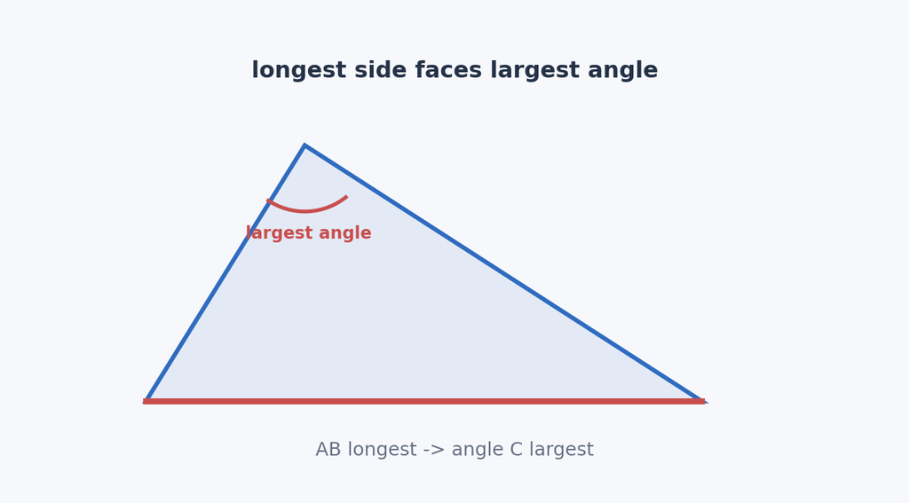

大邊對大角，大角對大邊

圖解：在三角形中標出最長邊與其對面的最大角。

## 座標距離與邊角比較

> 學習目標：座標平面中的邊角題，通常先用距離公式算邊長，再用大邊對大角比較角度。

### 解題流程

1. 列出三個點座標。
2. 分別計算三邊距離或距離平方。
3. 比較邊長大小。
4. 把最大邊換成對面的最大角。

### 易錯提醒

- 座標相減方向混亂，平方前就算錯。
- 算出最長邊後，忘記找它對面的角。

### 小練一下

- 兩點 (1,2)、(4,6) 的距離是多少？
- 若 CA 最大，哪一個角最大？

### 記憶鉤子

- 座標題先算邊，再回到大邊對大角。
- 比較根號大小時，比較根號內比較省力。

### 圖像化理解

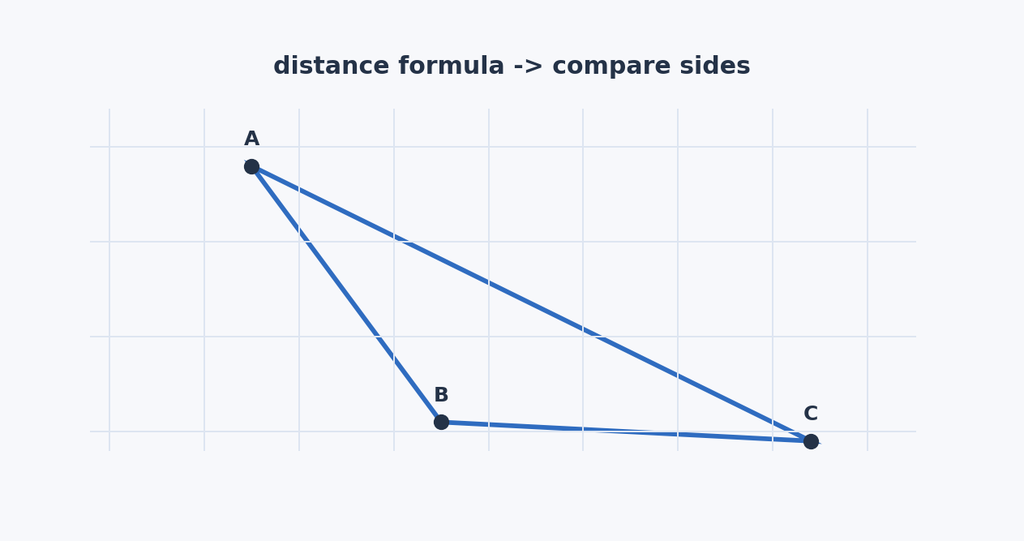

座標距離與邊角比較

圖解：用座標三角形示意先算距離，再比較對角。

## 方向、路線與滑行距離比較

> 學習目標：生活路線題可以先畫成三角形，再用角度大小判斷誰走得比較遠。

### 先抓住核心

- 東偏南、東偏北、西偏北等方向可以轉成三角形中的角。
- 若只問哪段距離較長，常不必精算長度，只要用大角對大邊。
- 若題目給 30°、60°、70° 等特殊角，可能可用三角函數或特殊直角三角形算實際距離。
- 若 70° 大於 60°，則 70° 對面的邊較長。
- 畫圖時先標出起點、方向線、相遇點，再比較三角形中的角。

### 解題流程

1. 把人物位置與相遇點畫成三角形。
2. 將方向角轉成三角形內角。
3. 若只比較長短，找大角對面的邊。
4. 若要長多少，再使用特殊角或三角函數計算。

### 公式、性質與判斷

- **比較長短**：大角對大邊。
- **60度直角三角形**：可用 1:sqrt(3):2。
- **方向題**：先畫圖再比較，不要只看文字方向。

### 例題拆解

- 若兩人滑行形成的三角形中，一段對 70°，另一段對 60°，則對 70° 的距離較長。
- 若直角三角形中有 60°，可用 30-60-90 比例求距離。
- 原講義中 70°>60°，所以乙滑行的距離較長。

### 易錯提醒

- 把方位角直接當成三角形內角，沒有看方向線夾角。
- 明明只問長短，卻陷入不必要計算。

### 小練一下

- 若一邊對 80°，另一邊對 45°，哪一邊較長？
- 方向題第一步應該先做什麼？

### 記憶鉤子

- 路線題不是先算，是先畫成三角形。
- 只比較長短時，大角對大邊往往比計算更快。

### 圖像化理解

[figure not shown]

方向、路線與滑行距離比較

圖解：用兩條滑行路線示意角度較大的一側對應較長路徑。